# HOMEWORK 1

```python
#monthly windows size
window_size = 26*20
```

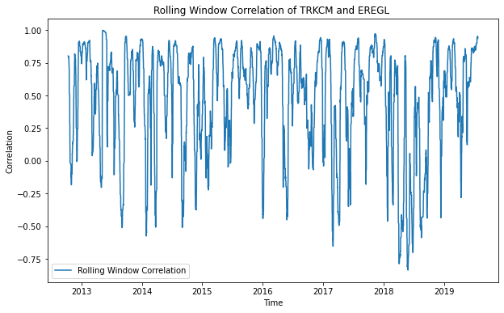

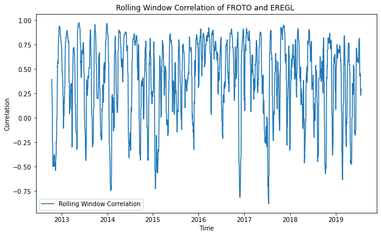

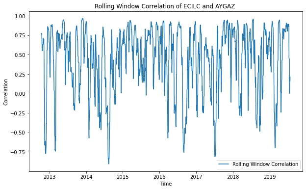

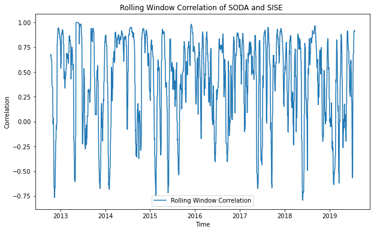

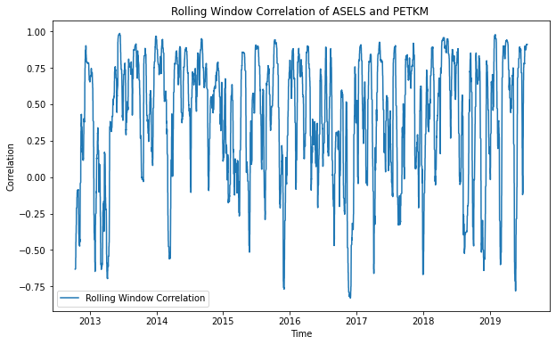

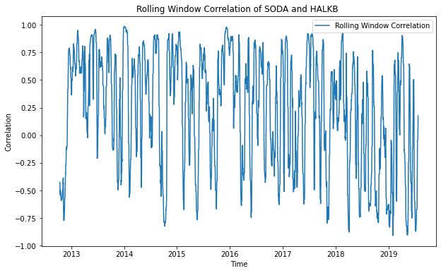

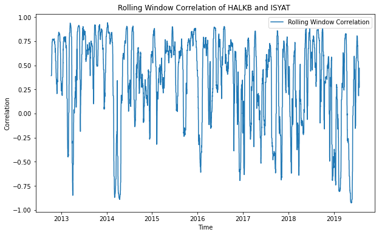

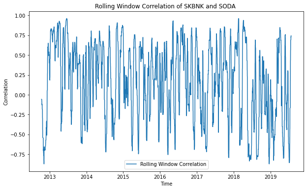

```python
for selected_pair in selected_pairs:
    rolling_corr = df[selected_pair[0]].rolling(window=window_size).corr(df[selected_pair[1]])

    plt.figure(figsize=(10, 6))
    plt.plot(df.index, rolling_corr, label='Rolling Window Correlation')

    plt.xlabel('Time')
    plt.ylabel('Correlation')
    plt.title(f"""Rolling Window Correlation of {selected_pair[0]} and {selected_pair[1]} """)
    plt.legend()
    plt.show()
```

# 4.3 PRINCIPAL COMPONENT ANALYSIS

PCA will be applied to stock prices to reduce dimensionality. Steps are scaling and appliying PCA. scaling step is important because PCA is sensitive to the scale of the variables. If we do not perform scaling, variables with larger scales can dominate the PCA results.

```python
pca = PCA()

#normalization
scaler=StandardScaler()
normalized_df = scaler.fit_transform(df)

#apply pca
pca_result = pca.fit_transform(normalized_df)

print(f'First principal component: \n {pca_result[1]}')
```

[output not shown]

The explained variance ratios indicate how much of the dataset's overall variability is captured by each individual principal component. When conducting Principal Component Analysis (PCA), components are organized in a way that reflects their respective contributions to the total variance. The first component accounts for the largest portion, followed by the second component, and so on.

```python
explained_variances = pca.explained_variance_ratio_
```

Loading scores quantify the level of connection between the original variables and the principal components. They reveal the degree to which each variable contributes to the makeup of each principal component. In other words, loading scores show how strongly each variable influences the composition of the derived components in the PCA process.

```python
loading_scores = pca.components_
```

```python
summary_df = pd.DataFrame({'Explained Variance Ratio': explained_variances})
summary_df['Principal Component'] = summary_df.index + 1
summary_df['Cumulative Variance Ratio'] = summary_df['Explained Variance Ratio'].cumsum()
summary_df
```

|  | Explained Variance Ratio | Principal Component | Cumulative Variance Ratio |
| --- | --- | --- | --- |
| 0 | 0.506189 | 1 | 0.506189 |
| 1 | 0.172579 | 2 | 0.678768 |
| 2 | 0.106116 | 3 | 0.784884 |
| 3 | 0.053525 | 4 | 0.838408 |
| 4 | 0.038369 | 5 | 0.876777 |
| 5 | 0.022268 | 6 | 0.899046 |
| 6 | 0.015065 | 7 | 0.914111 |
| 7 | 0.010671 | 8 | 0.924782 |
| 8 | 0.008939 | 9 | 0.933721 |
| 9 | 0.008036 | 10 | 0.941757 |
| 10 | 0.007864 | 11 | 0.949621 |
| 11 | 0.005928 | 12 | 0.955550 |
| 12 | 0.005399 | 13 | 0.960949 |
| 13 | 0.004719 | 14 | 0.965668 |
| 14 | 0.004121 | 15 | 0.969789 |
| 15 | 0.003098 | 16 | 0.972887 |
| 16 | 0.002799 | 17 | 0.975686 |
| 17 | 0.002440 | 18 | 0.978126 |
| 18 | 0.002304 | 19 | 0.980430 |
| 19 | 0.001879 | 20 | 0.982308 |
| 20 | 0.001655 | 21 | 0.983963 |
| 21 | 0.001416 | 22 | 0.985379 |
| 22 | 0.001247 | 23 | 0.986626 |
| 23 | 0.001167 | 24 | 0.987793 |
| 24 | 0.001069 | 25 | 0.988862 |
| 25 | 0.000970 | 26 | 0.989832 |
| 26 | 0.000935 | 27 | 0.990767 |
| 27 | 0.000833 | 28 | 0.991600 |
| 28 | 0.000770 | 29 | 0.992370 |
| 29 | 0.000711 | 30 | 0.993081 |
| 30 | 0.000652 | 31 | 0.993733 |
| 31 | 0.000631 | 32 | 0.994365 |
| 32 | 0.000553 | 33 | 0.994918 |
| 33 | 0.000499 | 34 | 0.995417 |
| 34 | 0.000480 | 35 | 0.995898 |
| 35 | 0.000419 | 36 | 0.996317 |
| 36 | 0.000368 | 37 | 0.996684 |
| 37 | 0.000332 | 38 | 0.997016 |
| 38 | 0.000308 | 39 | 0.997324 |
| 39 | 0.000272 | 40 | 0.997596 |
| 40 | 0.000245 | 41 | 0.997841 |
| 41 | 0.000238 | 42 | 0.998078 |
| 42 | 0.000219 | 43 | 0.998298 |
| 43 | 0.000186 | 44 | 0.998484 |
| 44 | 0.000183 | 45 | 0.998667 |
| 45 | 0.000162 | 46 | 0.998829 |
| 46 | 0.000147 | 47 | 0.998976 |
| 47 | 0.000140 | 48 | 0.999116 |
| 48 | 0.000128 | 49 | 0.999244 |
| 49 | 0.000123 | 50 | 0.999367 |
| 50 | 0.000103 | 51 | 0.999470 |
| 51 | 0.000095 | 52 | 0.999565 |
| 52 | 0.000084 | 53 | 0.999648 |
| 53 | 0.000079 | 54 | 0.999727 |
| 54 | 0.000069 | 55 | 0.999797 |
| 55 | 0.000063 | 56 | 0.999860 |
| 56 | 0.000055 | 57 | 0.999915 |
| 57 | 0.000046 | 58 | 0.999960 |
| 58 | 0.000040 | 59 | 1.000000 |

The following two graph shows that first component capyres 50% of cumulative variance and first 7 principal components capture more than cumulative variance of more than 90%.

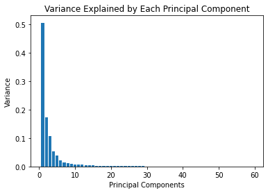

```python
num_components=len(summary_df)

plt.bar(range(1, num_components + 1), explained_variances)
plt.xlabel('Principal Components')
plt.ylabel('Variance')
plt.title('Variance Explained by Each Principal Component')
plt.show()
```

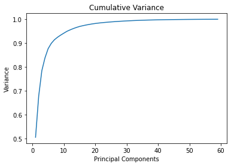

```python
plt.plot(range(1, num_components + 1), explained_variances.cumsum())
plt.xlabel('Principal Components')
plt.ylabel('Variance')
plt.title('Cumulative Variance')
plt.show()
```

These components can be seen as latent variables since they are not observed but can be represented as linear combination of inputs.

```python
df['p1']=pca_result[:,0]
df['p2']=pca_result[:,1]
df['p3']=pca_result[:,2]
df['p4']=pca_result[:,3]
df['p5']=pca_result[:,4]
df['p6']=pca_result[:,5]
df['p7']=pca_result[:,6]
```

```python
df.head()
```

| timestamp | AEFES | AKBNK | AKSA | AKSEN | ALARK | ALBRK | ANACM | ARCLK | ASELS | ASUZU | ... | YKBNK | YUNSA | ZOREN | p1 | p2 | p3 | p4 | p5 | p6 | p7 |
| --- | --- | --- | --- | --- | --- | --- | --- | --- | --- | --- | --- | --- | --- | --- | --- | --- | --- | --- | --- | --- | --- |
| 2012-09-17 06:45:00 | 22.3978 | 5.2084 | 1.7102 | 3.87 | 1.4683 | 1.1356 | 1.0634 | 6.9909 | 2.9948 | 2.4998 | ... | 2.5438 | 2.2619 | 0.7789 | -8.409077 | 0.706971 | -0.575593 | -4.346659 | 2.371941 | 3.828357 | -3.621272 |
| 2012-09-17 07:00:00 | 22.3978 | 5.1938 | 1.7066 | 3.86 | 1.4574 | 1.1275 | 1.0634 | 6.9259 | 2.9948 | 2.5100 | ... | 2.5266 | 2.2462 | 0.7789 | -8.430749 | 0.790024 | -0.565238 | -4.342699 | 2.387487 | 3.793562 | -3.627764 |
| 2012-09-17 07:15:00 | 22.3978 | 5.2084 | 1.7102 | 3.86 | 1.4610 | 1.1356 | 1.0679 | 6.9909 | 2.9855 | 2.4796 | ... | 2.5266 | 2.2566 | 0.7789 | -8.424555 | 0.786253 | -0.569487 | -4.359908 | 2.366674 | 3.800550 | -3.604408 |
| 2012-09-17 07:30:00 | 22.3978 | 5.1938 | 1.7102 | 3.86 | 1.4537 | 1.1275 | 1.0679 | 6.9584 | 2.9855 | 2.4897 | ... | 2.5324 | 2.2619 | 0.7860 | -8.419280 | 0.777832 | -0.552946 | -4.343059 | 2.376697 | 3.797850 | -3.611708 |
| 2012-09-17 07:45:00 | 22.5649 | 5.2084 | 1.7102 | 3.87 | 1.4574 | 1.1356 | 1.0725 | 6.9909 | 2.9760 | 2.4897 | ... | 2.5324 | 2.2619 | 0.7789 | -8.416832 | 0.747811 | -0.579925 | -4.337388 | 2.370570 | 3.820340 | -3.596758 |

5 rows × 66 columns

# INTERFERENCE WITH GOOGLE TRENDS

Google Trends offers insight into the frequency of specific search terms in comparison to the overall search volume worldwide.

```python
asels_trend=pd.read_csv("asels.csv",na_values=['nan','?'],infer_datetime_format=True)
asels_trend['timestamp']=pd.to_datetime(asels_trend['timestamp'], format='%Y-%m')
asels_trend.set_index('timestamp',inplace=True)
```

There is a paralel behaviour between Aselsan stock price movements and Google Trens results for Aselsan as can be seen from the graph. It is have a peak at November 2017.

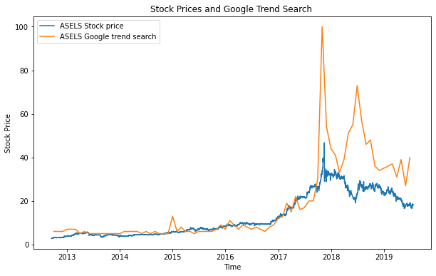

```python
stock1_prices = df['ASELS']
stock2_prices = asels_trend['ASELSAN']

plt.figure(figsize=(10, 6))
plt.plot(df.index, stock1_prices, label='ASELS Stock price')
plt.plot(asels_trend.index, stock2_prices, label='ASELS Google trend search')

plt.xlabel('Time')
plt.ylabel('Stock Price')
plt.title(f'Stock Prices and Google Trend Search ')
plt.legend()
plt.show()
```

The following new explains that in that month, Aselsan has become the largest publicly traded company in terms of market value. "Aselsan's shares, which have gained 245% in value since the beginning of the year, reached their peak today at 45.62 Turkish liras."

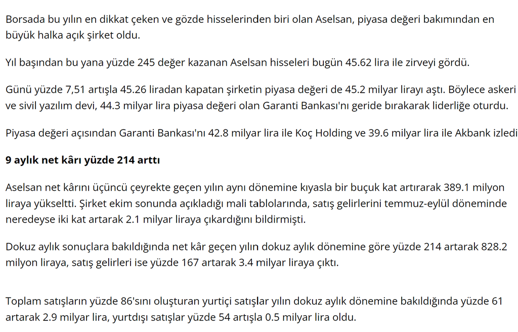

# APPENDIX

[figure not shown]